# Przewidywanie czasu adopcji psów ze Schroniska na Paluchu

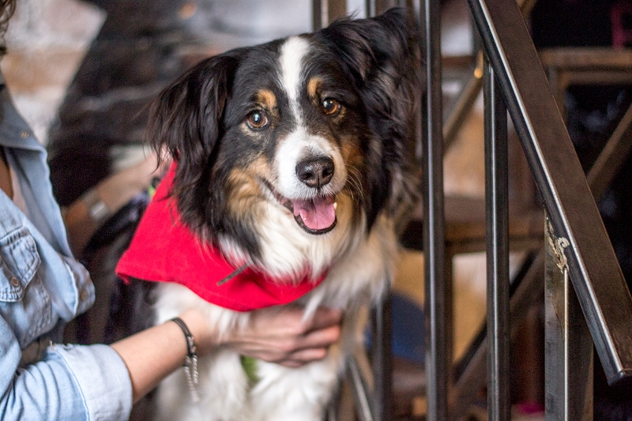

Pies Wilde, mieszkaniec schroniska w latach 2014-2017

## Wstęp

Schronisko dla Bezdomnych Zwierząt w Warszawie, znane też jako [Schronisko na Paluchu](https://napaluchu.waw.pl/) funkcjonuje od 2001 roku. Jego misją jest ochrona bezdomnych zwierząt, stwarzanie im drugiej szansy i bycie jedynie przystankiem na drodze między domami. Na dzień 30 kwietnia 2021 w schronisku znajdowało się 387 psów.

Celem projektu jest stworzenie algorytmu pozwalającego na przewidywanie czasu, w jakim zostanie adoptowany pies po przyjęciu do schroniska i odbyciu 15-dniowej kwarantanny. Wnioski mogą zostać użyte do zoptymalizowania ogłoszeń adopcyjnych tak, aby pobyt danego psa w schronisku mógł być jak najkrótszy.

## Pozyskanie surowych danych

Dane użyte do tego projektu zostały pozyskane ze strony internetowej [Schroniska na Paluchu](https://napaluchu.waw.pl/) przy pomocy web scrapingu w języku Python. Kod scrapera znajduje się w pliku *np_scraper.ipynb*. Outputem tego kodu jest baza danych *na_paluchu.db*.

## Przygotowanie danych

#### Instalacja i ładowanie bibliotek:

**dplyr** - pozwala na manipulację danymi (na wierszach i kolumnach),

**RSQLite** - dzięki niej można połączyć się z SQLite,

**stringr** - potrzebna do wykonywania operacji na ciągach znaków,

**reshape** - do zmiany struktury zbioru danych,

**ggplot2** - do wykonywania wykresów,

**tidyr** - do formatowania i przekształcania danych,

**gridExtra** - potrzebna do umieszczania grafiki (ggplot) obok siebie,

**rmdformats** - do wykorzystania gotowych motywów stron HTML,

**caret** - potrzebna ze względu na funkcje do modelowania i predykcji,

**naivebayes, RandomForest, xgboost, kerblab, e1071** - do wykorzystania konkretnych algorytmów.

```r
library(dplyr)
library(RSQLite)
library(stringr)
library(reshape)
library(ggplot2)
library(tidyr)
library(gridExtra)
library(rmdformats)
library(caret)
library(naivebayes)
library(randomForest)
library(xgboost)
library(kernlab)
library(e1071)
```

#### Łączenie się z bazą danych *na_paluchu.db*

Dostęp do danych za pomocą pakietu RSQLite

```r
con <- dbConnect(drv=RSQLite::SQLite(), dbname="na_paluchu.db")
tables <- dbListTables(con)
animals <- dbGetQuery(conn=con, statement=paste("SELECT * FROM pets;", sep=","))
dbDisconnect(con)
```

#### Eksploracja surowych danych

Obiekt *animals* jest ramką danych o wymiarach 20 010 wierszy na 12 kolumn. Wywołanie funkcji `str()` pokazuje też, że wszystkie wartości w kolumnach są typu **character**. W zestawie danych nie brakuje żadnych wartości (*NA*).

```r
str(animals)
```

```
## 'data.frame':    20010 obs. of  12 variables:
##  $ numer              : chr  "0323/21" "0502/21" "0584/21" "0586/21" ...
##  $ imie               : chr  "brak" "Amelka" "Spacja" "Apka" ...
##  $ w_typie_rasy       : chr  "Mieszaniec" "Beagle" "Mieszaniec" "Mieszaniec" ...
##  $ wiek               : chr  "1 rok" "5 lat" "1 miesiąc" "1 miesiąc" ...
##  $ plec               : chr  "samiec" "samica" "samica" "samica" ...
##  $ waga               : chr  "9 kg" "13 kg" "3 kg" "2 kg" ...
##  $ status             : chr  "wydane" "wydane" "wydane" "wydane" ...
##  $ data_przyjecia     : chr  "2021-02-26" "2021-03-28" "2021-04-13" "2021-04-13" ...
##  $ data_wydania       : chr  "2021-04-23" "2021-04-23" "2021-04-23" "2021-04-23" ...
##  $ miejsce_znalezienia: chr  "Warszawa, ul. Wielicka" "Warszawa ul. Ksawerów" "Warszawa, ul. Czorsztyńska" "Warszawa, ul. Czorsztyńska" ...
##  $ boks               : chr  "120 R2" "065 R4" "084 R3" "084 R3" ...
##  $ grupa              : chr  "G2" "Psubraty" "Psie Przedszkole" "Psie Przedszkole" ...
```

```r
sum(is.na(animals))
```

```
## [1] 0
```

- numer - nieunikalny identyfikator psa w dokumentacji schroniska (istnieje kilka duplikatów)
- imie - imię psa nadane w schronisku
- w_typie_rasy - pies wykazuje cechy rasowe w wyglądzie i zachowaniu, ale nie ma udokumentowanego pochodzenia
- wiek - wiek psa w momencie przyjęcia do schroniska (w miesiącach lub latach)
- plec - samiec, samica lub nn
- waga - masa psa w momencie przyjęcia do schroniska (w kilogramach)
- status - “wydane” dla wszystkich wierszy, w dalszych etapach ta kolumna będzie pominięta
- data_przyjecia - data w formacie *yyyy-mm-dd*
- data_wydania - data w formacie *yyyy-mm-dd*
- miejsce_znalezienia - ulica lub/i miasto, ewentualnie skąd pies znalazł się w schronisku; w dalszym etapie obserwacje z wartością “przepisana umowa” zostaną pominęte
- boks - miejsce na terenie schroniska
- grupa - grupa na Facebooku, na której wystawione jest ogłoszenie adopcyjne

Kolumna *numer* posiada duplikaty, które trzeba będzie usunąć:

```r
print(animals %>%
        count(numer) %>%
        arrange(desc(n)) %>%
        head())
```

```
##     numer n
## 1 0013/15 2
## 2 0014/15 2
## 3 0062/18 2
## 4 0128/20 2
## 5 0149/15 2
## 6 0152/16 2
```

Kolumna *w_typie_rasy* posiada 156 unikalnych wartości:

```r
length(unique(animals$w_typie_rasy))
```

```
## [1] 156
```

Kolumna *plec* posiada nieznane wartości:

```r
unique(animals$plec)
```

```
## [1] "samiec" "samica" "nn"
```

Kolumna *miejsce_znalezienia* posiada ponad 9 000 unikalnych wartości:

```r
length(unique(animals$miejsce_znalezienia))
```

```
## [1] 9761
```

Kolumna *boks* ma ponad 2 000 unikalnych wartości:

```r
length(unique(animals$boks))
```

```
## [1] 2414
```

Jako, że nie jest znana zasada przydzielania psów do boksu, a także znalezienie spójnego sposobu na pogrupowanie boksów jest prawie niemożliwe, w dalszych etapach ta kolumna zostanie pominięta.

#### Czyszczenie danych

Usuwanie duplikatów z kolumny *numer*

```r
animals <- animals[!(duplicated(animals$numer)), ]
```

Usuwanie wartości liczbowych z kolumny *imie*

```r
animals$imie[str_detect(animals$imie, "[0-9]{1}")] <- 'brak'
```

Pogrupowanie unikalnych wartości z kolumny *w_typie_rasy* w 15 grup na podstawie [klasyfikacji Międzynarodowej Federacji Kynologicznej](https://pl.wikipedia.org/wiki/Grupy_FCI) (zmienne kategoryczne na zmienne numeryczne):

- 1 - mieszaniec
- 2 - jamnik
- 3 - terier
- 4 - owczarek
- 5 - szpic/pies w typie pierwotnym
- 6 - aporter
- 7 - pies ozdobny/do towarzystwa
- 8 - płochacz
- 9 - molos
- 10 - pinczer/sznaucer
- 11 - wyżeł
- 12 - gończy
- 13 - szwajcarski pies pasterski
- 14 - chart
- 15 - inny

```r
animals <- animals %>%
  mutate(w_typie_rasy = tolower(w_typie_rasy))
#zmienna pomocnicza
w <- animals$w_typie_rasy

animals <- animals %>%
  mutate(rasa = ifelse(w %in% c("mieszaniec"), 1,
                       ifelse(w %in% c("jamnik"), 2,
                              ifelse(str_detect(w, "staff|ter+ier|highland|jack|pitbul|foks"), 3,
                                     ifelse(str_detect(w, "owczarek|collie|wilczak"), 4,
                                            ifelse(str_detect(w, "husky|malamut|akita|szpic|karelski|chow|shiba|.ajka|samojed"), 5,
                                                   ifelse(str_detect(w, "labrador|retriever|flat coat"), 6,
                                                          ifelse(str_detect(w, "peki.czyk|tzu|ratler|bulldog fra|pudel|malta|chih|king|grzywacz|biszon|mops"), 7,
                                                                 ifelse(str_detect(w, "spaniel"), 8,
                                                                        ifelse(str_detect(w, "bokser|rottweiler|bernardyn|molos|shar|cane|buldog|^dog|mastif|anatol|nowofund|leon|tosa"), 9,
                                                                               ifelse(str_detect(w, "sznaucer|pinczer|doberman"), 10,
                                                                                      ifelse(str_detect(w, "wy.e.|breton|seter|gordon"), 11,
                                                                                             ifelse(str_detect(w, "go.czy|posokowiec|ogar|basset|dalmaty|rhode|beagle"), 12,
                                                                                                    ifelse(str_detect(w, "berne.ski"), 13,
                                                                                                    ifelse(str_detect(w, "chart|wilczarz|greyh"), 14, 15))))))))))))))) %>%
  select(-w_typie_rasy)
```

Ujednolicenie wartości z kolumny *wiek* - zamiana lat na miesiące

```r
animals <- animals %>%
  mutate(wiek_msc = as.numeric(str_extract(wiek, "[0-9]{1,2}"))) %>%
  mutate(wiek_m = ifelse(str_detect(wiek, "mies"), wiek_msc, wiek_msc * 12)) %>%
  select(-wiek, -wiek_msc)
```

Zamiana wartości z kolumny *plec* z kategorycznych na numeryczne:

- 0 - samiec
- 1 - samica
- 2 - nn

```r
animals <- animals %>%
  mutate(plec2 = ifelse(plec == "samiec", 0, ifelse(plec == "samica", 1, 2))) %>%
  select(-plec)
```

Pomijanie jednostki w kolumnie *waga* i uzupełnianie wartości 0

```r
animals <- animals %>%
  mutate(waga_2 = as.numeric(str_extract(waga, "[0-9]{1,2}"))) %>%
  select(-waga)

agg1 <- aggregate(waga_2 ~ rasa,  animals,
                  median)
colnames(agg1) <- c("rasa","mediana")
animals <- animals %>% left_join(agg1, by = 'rasa')

animals <- animals %>%
  mutate(waga = ifelse(waga_2 == 0, as.numeric(mediana), waga_2)) %>%
  select(-waga_2) %>%
  select(-mediana)
```

Zamiana wartości z kolumn *data_przyjecia* i *data_wydania* na typ **date**, wyliczanie okresu pomiądzy dwoma datami, usuwanie obserwacji z datą wsteczną

```r
animals$data_przyjecia <- as.Date(animals$data_przyjecia, format = "%Y-%m-%d")
animals$data_wydania <- as.Date(animals$data_wydania, format = "%Y-%m-%d")

animals <- animals %>%
  mutate(roznica = data_wydania - data_przyjecia) %>%
  filter(roznica > 0 | roznica == 0)
```

Tworzenie nowej kolumny *przedzial* na podstawie długości okresu między datą przyjęcia do schroniska a datą wydania:

- 1 - kwarantanna (15 dni po przyjęciu do schroniska)
- 2 - do 1 miesiąca (16-30 dni)
- 3 - do 3 miesiący (31-91 dni)
- 4 - do 6 miesiący (92-183 dni)
- 5 - do roku (184-365 dni)
- 6 - do 5 lat (366-1826 dni)
- 7 - powyżej 5 lat

```r
animals <- animals %>%
  mutate(przedzial = ifelse(between(roznica, 0, 15), 1,
                            ifelse(between(roznica, 16,30), 2,
                                   ifelse(between(roznica, 31, 91), 3,
                                          ifelse(between(roznica, 92, 183), 4,
                                                 ifelse(between(roznica, 184, 365), 5,
                                                        ifelse(between(roznica, 366, 1826), 6, 7))))))) %>%
  select(-roznica)
```

Pogrupowanie unikalnych wartości z kolumny *miejsce_znalezienia* w 14 grup (zmienne kategoryczne na zmienne numeryczne):

- 1 - zwrot z adopcji
- 2 - Schronisko Radysy
- 3 - Fundacja Sfora
- 4 - brak informacji
- 5 - podrzucony pod schronisko
- 6 - Warszawa
- 7 - Raszyn
- 8 - z innego schroniska
- 9 - Piaseczno
- 10 - Góra Kalwaria
- 11 - Łomianki
- 12 - powrót z ucieczki
- 13 - po zmarłej osobie
- 14 - właściciel w izbie wytrzeźwień

```r
animals <- animals %>%
  filter(str_count(miejsce_znalezienia, "przepisanie") < 1)
#zmienna pomocnicza
m <- animals$miejsce_znalezienia

animals <- animals %>%
  mutate(miejsce = ifelse(str_detect(m, "adopcji"), 1,
                          ifelse(str_detect(m, "schronisko radysy"), 2,
                                 ifelse(str_detect(m, "fundacja sfora"), 3,
                                        ifelse(str_detect(m, "brak|sm ,|pies od nas"), 4,
                                               ifelse(str_detect(m, "[pod|przed|w|okolice|teren|okolic|do]{1} schroni"), 5,
                                                      ifelse(str_detect(m, "na skraj|raszy.ska|krakowska|warszawa|bia.o..ka|warszawy|warszawa"), 6,
                                                             ifelse(str_detect(m, "raszyn"), 7,
                                                                    ifelse(str_detect(m, "przekazanie ze schro|innego sch"), 8,
                                                                           ifelse(str_detect(m, "piaseczno|z.otok.os|chylice|zalesie g|go.l.w|mieszk.w|pilawa|bobrowiec"), 9,
                                                                                  ifelse(str_detect(m, "kalwaria|lka dworska"), 10,
                                                                                         ifelse(str_detect(m, "omianki"), 11,
                                                                                                ifelse(str_detect(m, "ucieczk"), 12,
                                                                                                       ifelse(str_detect(m, "zmar.ej"), 13,
                                                                                                              ifelse(str_detect(m, "sodon"), 14, 6))))))))))))))) %>%
  select(-miejsce_znalezienia)
```

Zamiana wartości z kolumny *grupa* z kategorycznych na numeryczne:

- 1 - brak
- 2 - [A](https://www.facebook.com/paluch.grupa.a/)
- 3 - [Asy](https://www.facebook.com/asoweadopcje/)
- 4 - [Fundacja](https://www.facebook.com/fundacjaprzyjacielepalucha/)
- 5 - [G1](https://www.facebook.com/wybieramkundelka/)
- 6 - [G11](https://www.facebook.com/11psichmarzen/)
- 7 - [G13](https://www.facebook.com/PSYjacieleGr13/)
- 8 - [G2](https://www.facebook.com/PokochajBezdomniaka/)
- 9 - [G4](https://www.facebook.com/odmienswiat/)
- 10 - [G6](https://www.facebook.com/psiakina6/)
- 11 - [G9](https://www.facebook.com/DDD.psie.adopcje/)
- 12 - [Geriatria](https://www.facebook.com/napaluchugeriatria/)
- 13 - [Grupa 7](https://www.facebook.com/Grupa7SchroniskoNaPaluchu/)
- 14 - [Kojoty](https://www.facebook.com/4%C5%81apy-do-adopcji-107079024418262)
- 15 - [MAKAK](https://www.facebook.com/kundelkinawydaniu/)
- 16 - [Pomaranczowi](https://www.facebook.com/pomaranczowi/)
- 17 - [Poziomki](https://www.facebook.com/PoziomkiZPalucha/)
- 18 - [Psie Przedszkole](https://www.facebook.com/pokochajmalucha)
- 19 - [Psubraty](https://www.facebook.com/GrupaPsubraty/)
- 20 - [Sfora](https://www.facebook.com/schroniskonapaluchu.grupasfora/)
- 21 - [TTB](https://www.facebook.com/Amstaffy-z-Palucha-1633315423594260/)
- 22 - [Wilki](https://www.facebook.com/wilkizpalucha/)
- 23 - [Zolte Boksy](https://www.facebook.com/grupabehawioralna/)

```r
grupy <- data.frame(c("brak",   "A",    "Asy",  "Fundacja", "G1",   "G11",  "G13",  "G2",   "G4",   "G6",   "G9",   "Geriatria",    "Grupa 7",  "Kojoty",   "MAKAK",    "Pomaranczowi", "Poziomki", "Psie Przedszkole", "Psubraty", "Sfora",    "TTB",  "Wilki",    "Zolte Boksy"),
                    c(1,    2,  3,  4,  5,  6,  7,  8,  9,  10, 11, 12, 13, 14, 15, 16, 17, 18, 19, 20, 21, 22, 23))
colnames(grupy) <- c("grupa","nr_grupy")

animals <- animals %>% left_join(grupy, by = 'grupa')
replc <- animals$grupa
replc[is.na(replc)] <- 'brak'
```

Usuwanie niepotrzebnych kolumn, zmiana nazw kolumn na bardziej czytelne

```r
animals <- animals %>%
  select(-status, -boks, -grupa) %>%
  dplyr::rename(wiek = wiek_m, plec = plec2, grupa = nr_grupy) %>%
  relocate(przedzial, .after  = grupa)
```

## Analiza danych

Po powyższych przekształceniach obiekt *animals* prezentuje się następująco:

```r
str(animals)
```

```
## 'data.frame':    19951 obs. of  11 variables:
##  $ numer         : chr  "0323/21" "0502/21" "0584/21" "0586/21" ...
##  $ imie          : chr  "brak" "Amelka" "Spacja" "Apka" ...
##  $ data_przyjecia: Date, format: "2021-02-26" "2021-03-28" ...
##  $ data_wydania  : Date, format: "2021-04-23" "2021-04-23" ...
##  $ rasa          : num  1 12 1 1 1 1 1 1 1 1 ...
##  $ wiek          : num  12 60 1 1 12 7 96 36 12 12 ...
##  $ plec          : num  0 1 1 1 0 1 0 0 1 0 ...
##  $ waga          : num  9 13 3 2 17 5 18 29 17 17 ...
##  $ miejsce       : num  6 6 6 6 6 4 6 11 6 6 ...
##  $ grupa         : num  8 19 18 18 6 15 11 3 15 7 ...
##  $ przedzial     : num  3 2 1 1 3 3 3 4 3 3 ...
```

```r
summary(animals)
```

```
##     numer               imie           data_przyjecia        data_wydania
##  Length:19951       Length:19951       Min.   :2001-09-17   Min.   :2013-08-13
##  Class :character   Class :character   1st Qu.:2014-12-19   1st Qu.:2015-05-16
##  Mode  :character   Mode  :character   Median :2017-01-11   Median :2017-05-03
##                                        Mean   :2016-10-16   Mean   :2017-05-03
##                                        3rd Qu.:2018-12-30   3rd Qu.:2019-03-15
##                                        Max.   :2021-04-19   Max.   :2021-04-23
##
##       rasa             wiek             plec             waga
##  Min.   : 1.000   Min.   :  0.00   Min.   :0.0000   Min.   : 1.00
##  1st Qu.: 1.000   1st Qu.: 60.00   1st Qu.:0.0000   1st Qu.: 8.00
##  Median : 1.000   Median : 84.00   Median :0.0000   Median :12.00
##  Mean   : 2.017   Mean   : 98.62   Mean   :0.4112   Mean   :15.67
##  3rd Qu.: 1.000   3rd Qu.:132.00   3rd Qu.:1.0000   3rd Qu.:22.00
##  Max.   :15.000   Max.   :312.00   Max.   :2.0000   Max.   :89.00
##
##     miejsce           grupa          przedzial
##  Min.   : 1.000   Min.   : 1.000   Min.   :1.000
##  1st Qu.: 6.000   1st Qu.: 1.000   1st Qu.:1.000
##  Median : 6.000   Median : 1.000   Median :2.000
##  Mean   : 5.633   Mean   : 2.593   Mean   :2.578
##  3rd Qu.: 6.000   3rd Qu.: 1.000   3rd Qu.:4.000
##  Max.   :13.000   Max.   :22.000   Max.   :7.000
##                   NA's   :123
```

Ramka danych *animals* posiada teraz 19 951 wierszy i 11 kolumn. Dwie kolumny mają typ **date**, dwie kolumny - typ tekstowy, reszta to dane numeryczne.

#### Macierz i mapa korelacji

Tworzenie mapy korelacji za pomocą bibliotek `dplyr, reshape, ggplot2` - aby sprawdzić czy są zależności liniowe między zmiennymi numerycznymi

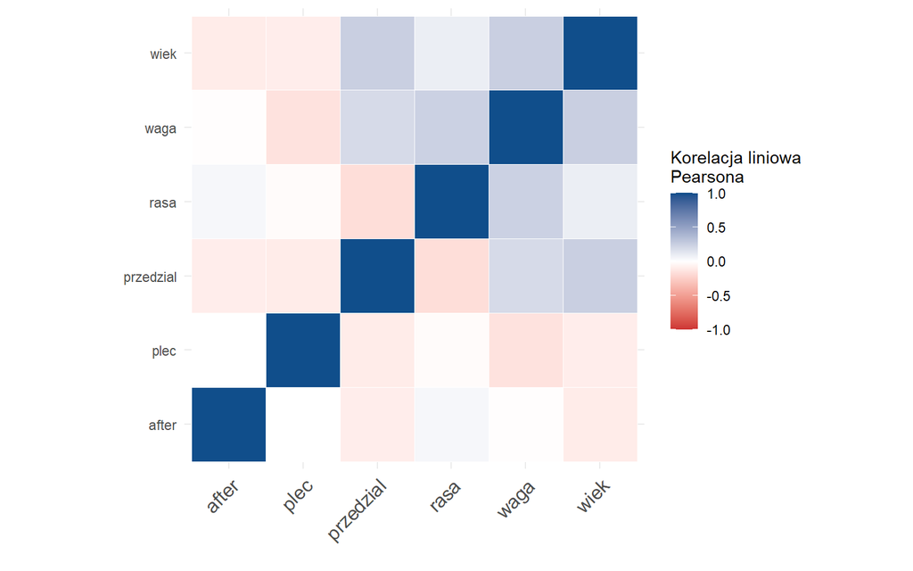

```r
M1 <- animals %>%
  select(-numer, -imie, -data_przyjecia, -data_wydania, -grupa) %>%
  relocate(przedzial, after = miejsce)
M2 <- round(cor(M1), 2)

#mapa korelacji
melted_M2 <- melt(M2)

ggplot(data = melted_M2, aes(x = X1, y = X2, fill = value)) +
  geom_tile(color = "white")+
  scale_fill_gradient2(low = "brown3", high = "dodgerblue4", mid = "white",
                       midpoint = 0, limit = c(-1,1), space = "Lab",
                       name="Korelacja liniowa\nPearsona") +
  theme_minimal() +
  theme(axis.text.x = element_text(angle = 45, vjust = 1,
                                   size = 12, hjust = 1)) +
  coord_fixed() + xlab("") + ylab("")
```

Z mapy korelacji wynika, że największy wpływ na szybkość adopcji może mieć wiek psa (w porównaniu z innymi badanymi czynnikami).

#### Wybrane miary dla zmiennej *imie*

Najpopularniejszymi imionami nadawanymi w Schronisku na Paluchu są Luna (dla samic) i Bruno (dla samców).

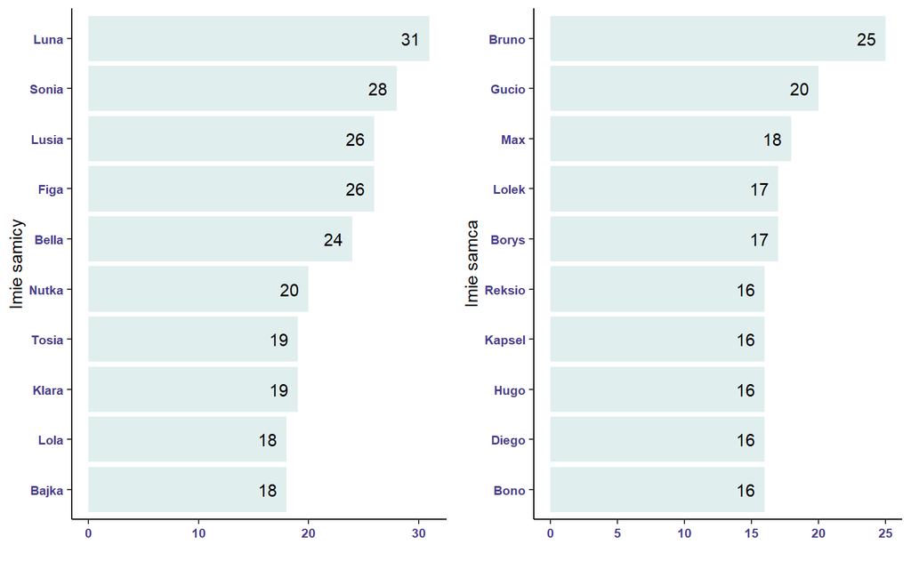

```r
top_imie_f <- animals %>%
  filter(plec == 1) %>%
  count(imie) %>%
  arrange(desc(n)) %>%
  filter(imie != "brak") %>%
  top_n(10)

top_imie_m <- animals %>%
  filter(plec == 0) %>%
  count(imie) %>%
  arrange(desc(n)) %>%
  filter(imie != "brak") %>%
  top_n(10)

plot_f <- ggplot(top_imie_f, aes(x = reorder(imie, desc(-n)), y = n, main="Najpopularniejsze imie dla samic")) +
  geom_bar(stat = "identity", fill = "azure2") +
  coord_flip() + scale_y_continuous(name="") +
  scale_x_discrete(name="Imie samicy") +
  theme(axis.text.x = element_text(face="bold", color="darkslateblue",
                                   size=8, angle=0),
        axis.text.y = element_text(face="bold", color="darkslateblue",
                                   size=8, angle=0)) +
  geom_text(aes(label = n, hjust = 1.5))
plot_m <- ggplot(top_imie_m, aes(x = reorder(imie, desc(-n)), y = n, main="Najpopularniejsze imie dla samcow")) +
  geom_bar(stat = "identity", fill = "azure2") +
  coord_flip() + scale_y_continuous(name="") +
  scale_x_discrete(name="Imie samca") +
  theme(axis.text.x = element_text(face="bold", color="darkslateblue",
                                   size=8, angle=0),
        axis.text.y = element_text(face="bold", color="darkslateblue",
                                   size=8, angle=0)) +
  geom_text(aes(label = n, hjust = 1.5))
grid.arrange(plot_f, plot_m, ncol = 2)
```

#### Trend i sezonowość

Przygotowanie danych do badania daty przyjęcia i daty wydania

```r
#sprawdzanie pelnych lat danych w dacie przyjecia
check_przy <- animals %>%
  mutate(mr_przy = format(animals$data_przyjecia, "%m-%Y")) %>%
  mutate(r_przy = format(animals$data_przyjecia, "%Y")) %>%
  select(mr_przy, r_przy) %>%
  group_by(r_przy) %>%
  summarise(ilosc_m = n_distinct(mr_przy)) %>%
  filter(ilosc_m == 12)

#sprawdzanie pelnych lat danych w dacie wydania
check_wyd <- animals %>%
  mutate(mr_wyd = format(animals$data_wydania, "%m-%Y")) %>%
  mutate(r_wyd = format(animals$data_wydania, "%Y")) %>%
  select(mr_wyd, r_wyd) %>%
  group_by(r_wyd) %>%
  summarise(ilosc_m = n_distinct(mr_wyd)) %>%
  filter(ilosc_m == 12)

#wyliczanie minimum i maksimum
min_przy <- as.numeric(min(check_przy$r_przy))
min_wyd <- as.numeric(min(check_wyd$r_wyd))
max_przy <- as.numeric(max(check_przy$r_przy))
max_wyd <- as.numeric(max(check_wyd$r_wyd))

#wyciaganie roku i miesiaca
animals_1 <- animals %>%
  mutate(msc_przyjecia = format(animals$data_przyjecia, "%m")) %>%
  mutate(msc_wydania = format(animals$data_wydania, "%m")) %>%
  mutate(rok_przyjecia = format(animals$data_przyjecia, "%Y")) %>%
  mutate(rok_wydania = format(animals$data_wydania, "%Y"))

sezon_przyjecie <- animals_1 %>%
  group_by(rok_przyjecia, msc_przyjecia) %>%
  summarize(ilosc_przyjec = n()) %>%
  arrange(rok_przyjecia) %>%
  filter(rok_przyjecia >= min_przy & rok_przyjecia <= max_przy)

sezon_wydanie <- animals_1 %>%
  group_by(rok_wydania, msc_wydania) %>%
  summarize(ilosc_przyjec = n()) %>%
  arrange(rok_wydania) %>%
  filter(rok_wydania >= min_wyd & rok_wydania <= max_wyd)
```

Tabela przedstawiająca ilość zwierząt przyjętych w danym roku i miesiącu

```r
sezon3a <- sezon_przyjecie %>%
  pivot_wider(names_from = msc_przyjecia, values_from = ilosc_przyjec) %>%
  arrange(rok_przyjecia)
```

| rok_przyjecia | 01 | 02 | 03 | 04 | 05 | 06 | 07 | 08 | 09 | 10 | 11 | 12 |
| --- | --- | --- | --- | --- | --- | --- | --- | --- | --- | --- | --- | --- |
| 2005 | 5 | 3 | 4 | 5 | 5 | 4 | 4 | 7 | 4 | 7 | 6 | 9 |
| 2006 | 9 | 7 | 11 | 14 | 6 | 8 | 8 | 11 | 5 | 6 | 11 | 18 |
| 2007 | 11 | 10 | 17 | 6 | 11 | 11 | 6 | 7 | 14 | 12 | 8 | 7 |
| 2008 | 9 | 12 | 11 | 14 | 16 | 14 | 14 | 10 | 12 | 10 | 3 | 4 |
| 2009 | 5 | 11 | 18 | 7 | 13 | 14 | 10 | 8 | 14 | 7 | 8 | 18 |
| 2010 | 12 | 8 | 21 | 7 | 8 | 13 | 11 | 11 | 14 | 18 | 12 | 17 |
| 2011 | 16 | 14 | 15 | 16 | 17 | 16 | 14 | 19 | 21 | 13 | 12 | 17 |
| 2012 | 25 | 14 | 17 | 16 | 13 | 18 | 30 | 23 | 25 | 28 | 30 | 25 |
| 2013 | 46 | 24 | 44 | 45 | 54 | 72 | 90 | 181 | 212 | 203 | 215 | 210 |
| 2014 | 230 | 183 | 191 | 168 | 193 | 184 | 203 | 215 | 205 | 235 | 234 | 265 |
| 2015 | 238 | 199 | 212 | 193 | 193 | 171 | 220 | 191 | 175 | 193 | 163 | 223 |
| 2016 | 243 | 207 | 161 | 200 | 203 | 191 | 218 | 167 | 190 | 178 | 201 | 261 |
| 2017 | 215 | 191 | 203 | 195 | 181 | 177 | 242 | 201 | 206 | 201 | 218 | 223 |
| 2018 | 253 | 192 | 233 | 228 | 193 | 166 | 233 | 199 | 237 | 225 | 241 | 257 |
| 2019 | 230 | 205 | 272 | 215 | 206 | 187 | 231 | 206 | 187 | 163 | 244 | 186 |
| 2020 | 210 | 203 | 140 | 119 | 111 | 159 | 269 | 180 | 180 | 200 | 120 | 161 |

```r
high_p <- max.col(sezon3a[-1]) %>% as.vector()
sort(table(high_p), decreasing = TRUE)[1:1]
```

```
## 12
##  5
```

Tabela przedstawiająca ilość zwierząt wydanych w danym roku i miesiącu

```r
sezon3b <- sezon_wydanie %>%
  pivot_wider(names_from = msc_wydania, values_from = ilosc_przyjec) %>%
  arrange(rok_wydania)
```

| rok_wydania | 01 | 02 | 03 | 04 | 05 | 06 | 07 | 08 | 09 | 10 | 11 | 12 |
| --- | --- | --- | --- | --- | --- | --- | --- | --- | --- | --- | --- | --- |
| 2014 | 247 | 218 | 269 | 212 | 225 | 207 | 215 | 227 | 240 | 243 | 246 | 215 |
| 2015 | 274 | 221 | 256 | 257 | 229 | 206 | 199 | 249 | 230 | 191 | 185 | 211 |
| 2016 | 277 | 185 | 226 | 229 | 187 | 181 | 204 | 220 | 202 | 205 | 204 | 241 |
| 2017 | 265 | 202 | 200 | 168 | 193 | 201 | 212 | 220 | 209 | 231 | 200 | 237 |
| 2018 | 244 | 179 | 246 | 245 | 185 | 189 | 194 | 217 | 241 | 235 | 251 | 241 |
| 2019 | 241 | 247 | 286 | 211 | 188 | 191 | 204 | 249 | 201 | 222 | 242 | 210 |
| 2020 | 212 | 195 | 229 | 166 | 149 | 156 | 142 | 197 | 217 | 246 | 206 | 163 |

Miesiącem z najwyższą liczbą wydań jest styczeń (3 lata z 7 dostępnych)

```r
high_p <- max.col(sezon3b[-1]) %>% as.vector()
sort(table(high_p), decreasing = TRUE)[1:1]
```

```
## 1
## 3
```

Zmiana ilości w czasie

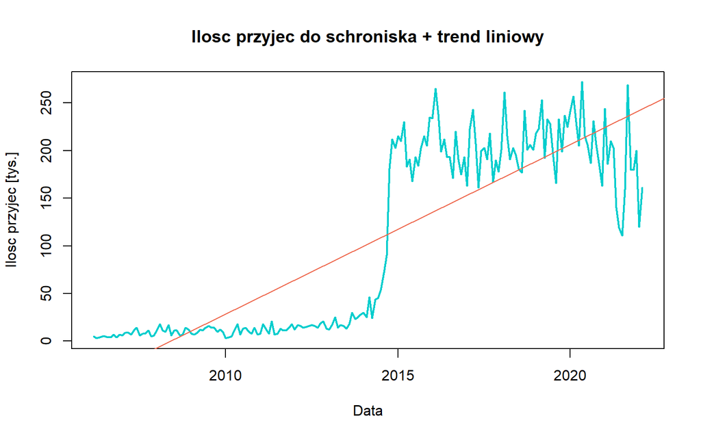

```r
b <- sezon_przyjecie$ilosc_przyjec
b <- ts(b, frequency = 12, start = c(2005, 15))
c <- sezon_wydanie$ilosc_przyjec
c <- ts(c, frequency = 12, start = c(2013, 7))

plot(b, xlab = "Data", ylab = "Ilosc przyjec [tys.]", col = "cyan3", lwd = 2, main = "Ilosc przyjec do schroniska + trend liniowy")
abline(lm(b ~ time(b)), col = "coral2")
```

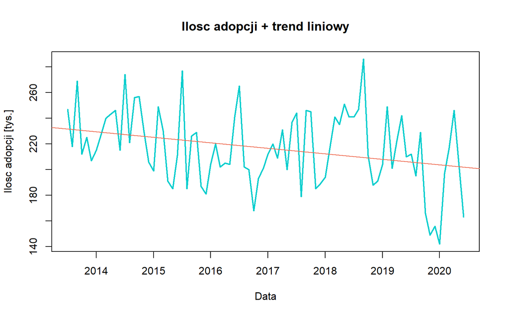

```r
plot(c, xlab = "Data", ylab = "Ilosc adopcji [tys.]", col = "cyan3", lwd = 2, main = "Ilosc adopcji + trend liniowy")
abline(lm(c ~ time(c)), col = "coral2")
```

Dekompozycja addytywna i multiplikatywna szeregów czasowych

→ dla daty przyjęcia

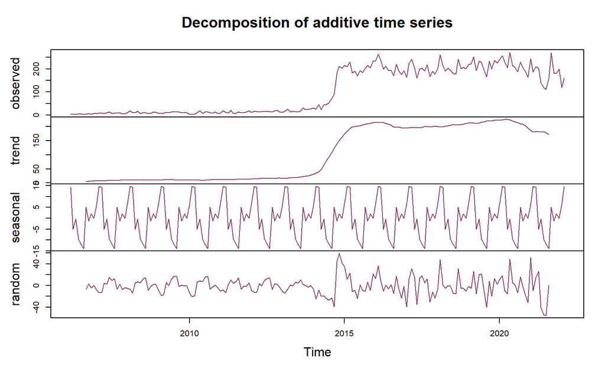

```r
plot(decompose(b), col = "hotpink4")
```

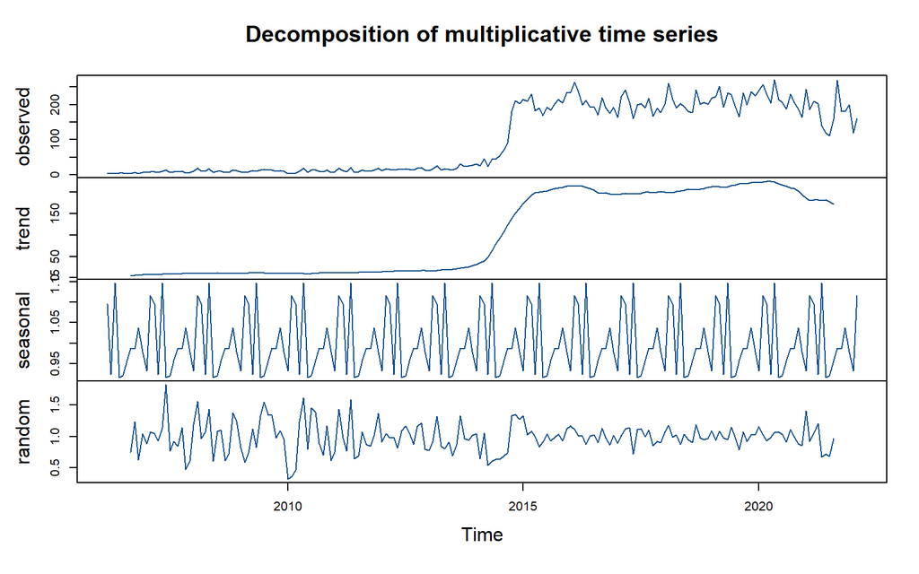

```r
plot(decompose(b, type = "multiplicative"), col = "dodgerblue4")
```

→ dla daty wydania

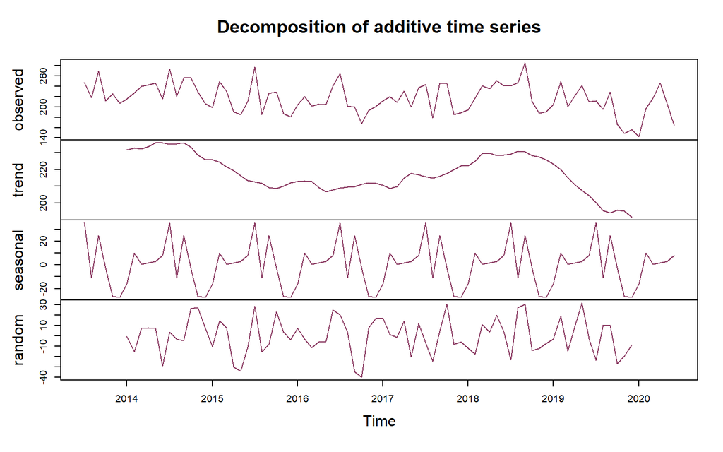

```r
plot(decompose(c), col = "hotpink4")
```

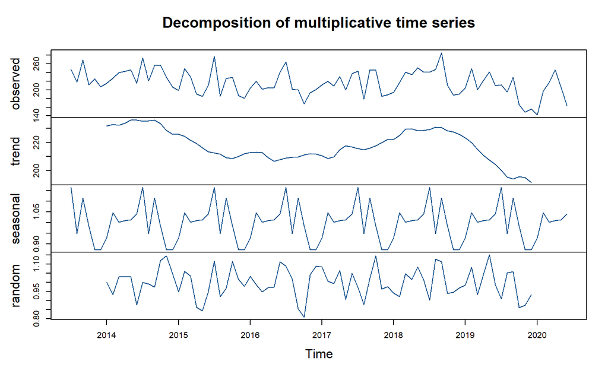

```r
plot(decompose(c, type = "multiplicative"), col = "dodgerblue4")
```

Pomimo poddania danych dekompozycji, nie jesteśmy w stanie stwierdzić sezonowości addytywnej ani multiplikatywnej - wykres wahań losowych wskazuje duży ich wpływ na zjawiska przyjęcia do schroniska i adopcji.

#### Wybrane miary dla zmiennej *rasa*

**Diagram Pareto** pokazuje, że ponad 75% psów wydanych to mieszańce.

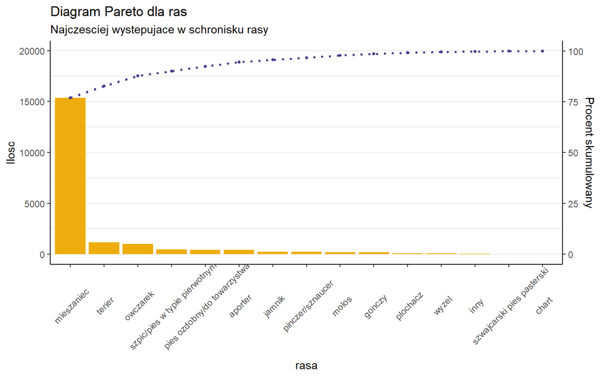

```r
r1 <- animals %>%
  count(rasa) %>%
  arrange(rasa)
v1 <- unlist(r1$n)
xVariable <- c("mieszaniec", "jamnik", "terier", "owczarek", "szpic/pies w typie pierwotnym", "aporter", "pies ozdobny/do towarzystwa", "plochacz", "molos", "pinczer/sznaucer", "wyzel", "gonczy", "szwajcarski pies pasterski", "chart", "inny")

R1 <- data.frame(count=v1, rasa=xVariable, stringsAsFactors = FALSE)
R1 <- R1[order(R1$count, decreasing=TRUE), ]
R1$rasa <- factor(R1$rasa, levels=R1$rasa)
R1$cumulative <- cumsum(R1$count)
total <- sum(R1$count)

ggplot(R1, aes(x = rasa)) +
  geom_bar(aes(y=count), fill='darkgoldenrod2', stat="identity") +
  geom_point(aes(y=cumulative), color = "darkslateblue", pch=16, size=1) +
  geom_path(aes(y=cumulative, group=1), colour="darkslateblue", lty=3, size=0.9) +
  theme(axis.text.x = element_text(angle=45, vjust=0.6),
        panel.grid.minor.y = element_line(color = "gray92"), panel.grid.major.y = element_line(color = "gray92")) +
  labs(title = "Diagram Pareto dla ras", subtitle = "Najczesciej wystepujace w schronisku rasy") +
  scale_y_continuous(name = "Ilosc",
    sec.axis = sec_axis( trans=~(./total)*100, name="Procent skumulowany"))
```

#### Wybrane miary dla zmiennej *wiek*

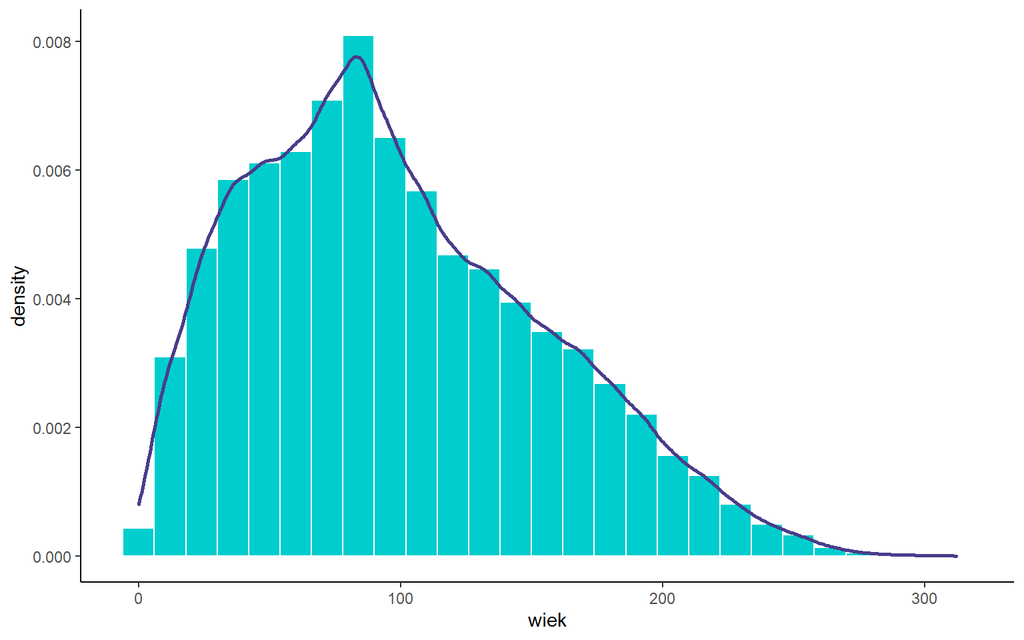

```r
ggplot(animals, aes(x=wiek)) +
  geom_histogram(aes(y=..density..), binwidth = 12, colour="white", fill="cyan3") +
  geom_density(size=1, colour="darkslateblue")
```

**Wykres punktowy** pokazuje, że szczeniaki i młode psy są najczęściej adoptowane do 91 dni od przybycia do schroniska.

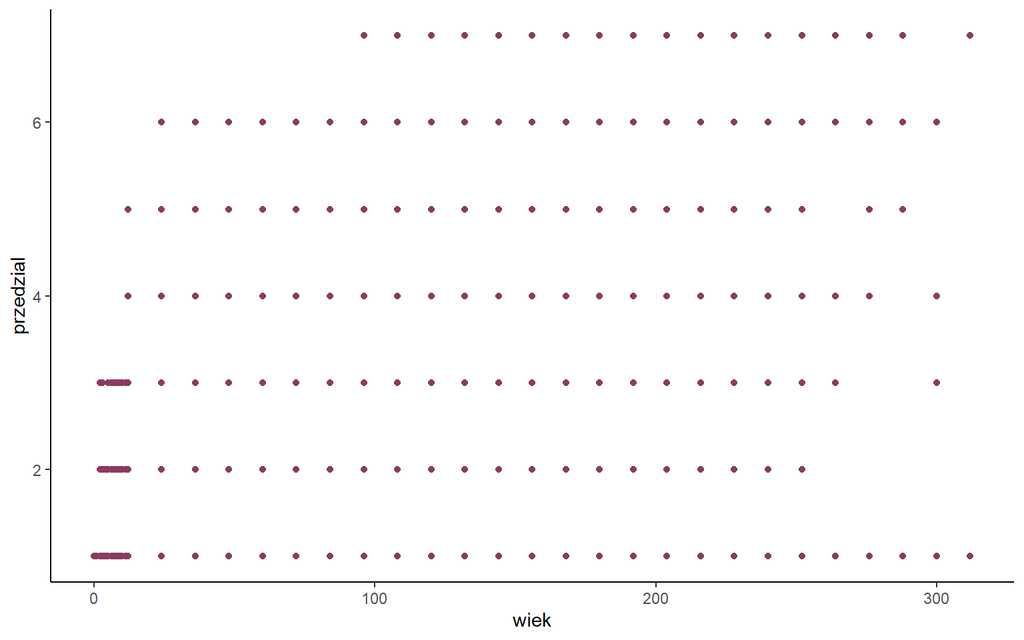

```r
ggplot(animals, aes(x=wiek, y=przedzial)) +
  geom_point(color = "hotpink4")
```

#### Wybrane miary dla zmiennej *waga*

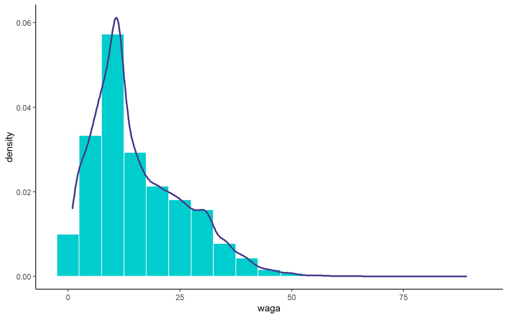

```r
ggplot(animals, aes(x=waga)) +
  geom_histogram(aes(y=..density..), binwidth = 5, colour="white", fill="cyan3") +
  geom_density(size=1, colour="darkslateblue")
```

**Wykres punktowy** pokazuje, że psy o masie powyżej 60 kg są bardzo rzadko adoptowane (lub/i w ogóle rzadko występują.

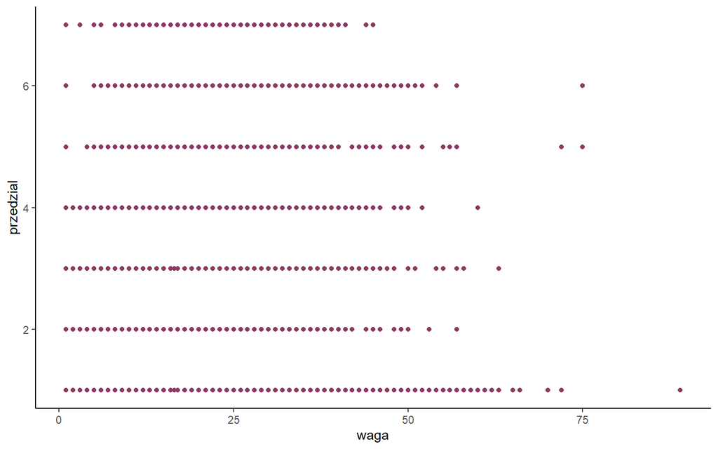

```r
ggplot(animals, aes(x=waga, y=przedzial)) +
  geom_point(color = "hotpink4")
```

#### Wartości procentowe dla zmiennej *plec*

**Wykres kołowy donut** - prawie 60% psów w schronisku to samce.

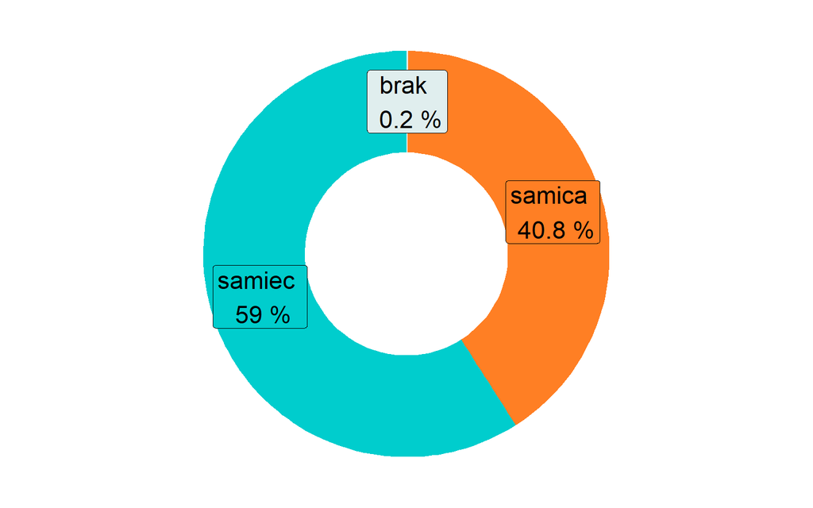

```r
sex <- animals %>%
  mutate(plec1 = ifelse(plec == 0, "samiec", ifelse(plec == 1, "samica", "brak"))) %>%
  select(plec1) %>%
  group_by(plec1) %>%
  count(plec1)
sex$procent = sex$n / sum (sex$n) *100
sex$ymax = cumsum(sex$procent)
sex$ymin = c(0, head(sex$ymax, n=-1))
sex$labelPosition <- (sex$ymax + sex$ymin) / 2
sex$label <- paste(sex$plec1, "\n", round(sex$procent,1), "%")

ggplot(sex, aes(ymax=ymax, ymin=ymin, xmax=4, xmin=3, fill=plec1)) +
  geom_rect() +
  geom_label(x=3.5, aes(y=labelPosition, label=label), size=6) +
  scale_fill_manual(values=c("azure2", "chocolate1", "cyan3")) +
  coord_polar(theta="y") +
  xlim(c(2, 4)) +
  theme_void() +
  theme(legend.position = "none")
```

#### Diagram Pareto dla zmiennej *miejsce*

Możemy zauważyć, że 80% psów w schronisku zostało znalezionych w Warszawie.

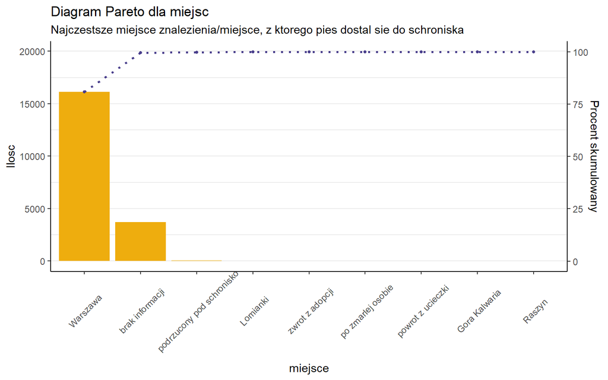

```r
ms1 <- animals %>%
  count(miejsce) %>%
  arrange(miejsce)

ms_v1 <- unlist(ms1$n)
xVariable <- c("zwrot z adopcji", "brak informacji", "podrzucony pod schronisko", "Warszawa", "Raszyn", "Gora Kalwaria", "Lomianki", "powrot z ucieczki", "po zmarlej osobie")

MS1 <- data.frame(count=ms_v1, miejsce=xVariable, stringsAsFactors = FALSE)
MS1 <- MS1[order(MS1$count, decreasing=TRUE), ]
MS1$miejsce <- factor(MS1$miejsce, levels=MS1$miejsce)
MS1$cumulative <- cumsum(MS1$count)
total <- sum(MS1$count)

ggplot(MS1, aes(x = miejsce)) +
  geom_bar(aes(y=count), fill='darkgoldenrod2', stat="identity") +
  geom_point(aes(y=cumulative), color = "darkslateblue", pch=16, size=1) +
  geom_path(aes(y=cumulative, group=1), colour="darkslateblue", lty=3, size=0.9) +
  theme(axis.text.x = element_text(angle=45, vjust=0.6),
        panel.grid.minor.y = element_line(color = "gray92"), panel.grid.major.y = element_line(color = "gray92")) +
  labs(title = "Diagram Pareto dla miejsc", subtitle = "Najczestsze miejsce znalezienia/miejsce, z ktorego pies dostal sie do schroniska") +
  scale_y_continuous(name = "Ilosc",
                     sec.axis = sec_axis( trans=~(./total)*100, name="Procent skumulowany"))
```

#### Wybrane miary dla zmiennej *grupa*

Zdecydowana większość psów na stronie schroniska nie była “reklamowana” na Facebooku

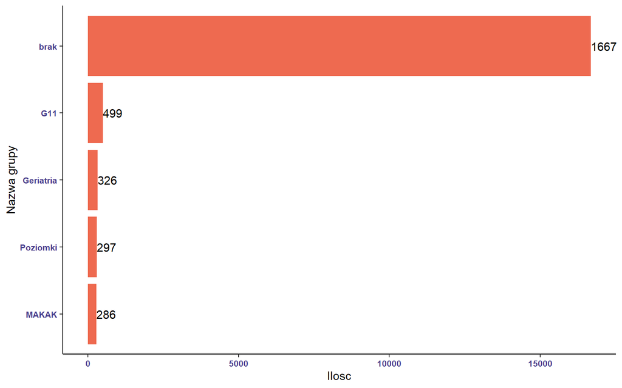

```r
gr_1 <- animals %>%
  count(grupa) %>%
  arrange(desc(n)) %>%
  top_n(5)

gr_1 <- gr_1 %>%
  left_join(grupy, by = c('grupa'='nr_grupy')) %>%
  select(-grupa) %>%
  relocate(grupa.y, .before = n)

ggplot(gr_1, aes(x = reorder(grupa.y, desc(-n)), y = n)) +
  geom_bar(stat = "identity", fill = "coral2") +
  coord_flip() + scale_y_continuous(name="Ilosc") +
  scale_x_discrete(name="Nazwa grupy") +
  theme(axis.text.x = element_text(face="bold", color="darkslateblue",
                                   size=8, angle=0),
        axis.text.y = element_text(face="bold", color="darkslateblue",
                                   size=8, angle=0)) +
  geom_text(aes(label = n, hjust = 0))
```

Po pominięciu obserwacji z wartością “brak”, największą popularnością cieszą się psy z grup G11, Geriatria i Poziomki.

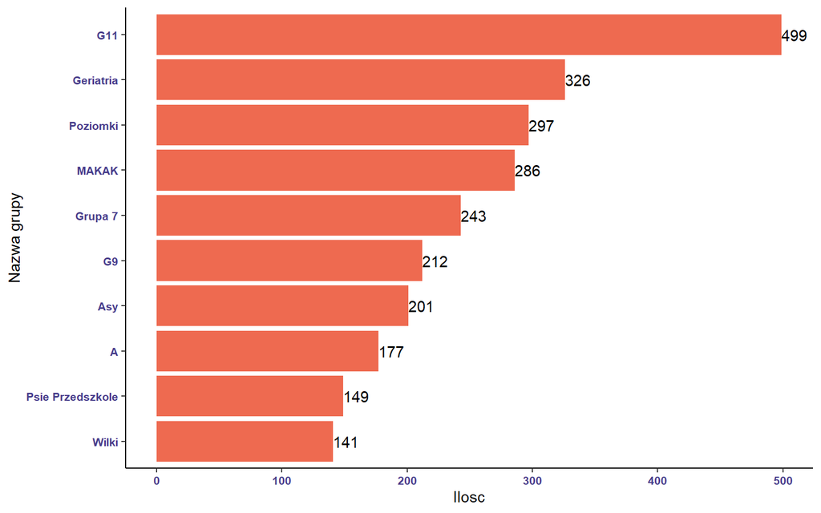

```r
gr_1a <- animals %>%
  count(grupa) %>%
  arrange(desc(n)) %>%
  top_n(11)

gr_1a <- gr_1a %>%
  left_join(grupy, by = c('grupa'='nr_grupy')) %>%
  select(-grupa) %>%
  relocate(grupa.y, .before = n) %>%
  filter(grupa.y != "brak")

ggplot(gr_1a, aes(x = reorder(grupa.y, desc(-n)), y = n)) +
  geom_bar(stat = "identity", fill = "coral2") +
  coord_flip() + scale_y_continuous(name="Ilosc") +
  scale_x_discrete(name="Nazwa grupy") +
  theme(axis.text.x = element_text(face="bold", color="darkslateblue",
                                   size=8, angle=0),
        axis.text.y = element_text(face="bold", color="darkslateblue",
                                   size=8, angle=0)) +
  geom_text(aes(label = n, hjust = 0))
```

#### Ilość adoptowanych zwierząt wg zmiennej *przedzial*

Najwięcej psów jest zabieranych ze schroniska podczas przebywania na kwarantannie (prawdopodobnie są to zaginione zwierzęta, które potem zostały odebrane przez właścicieli). Kolejną najliczniejszą grupą są psy adoptowane pomiędzy pierwszym a trzecim miesięcem pobytu.

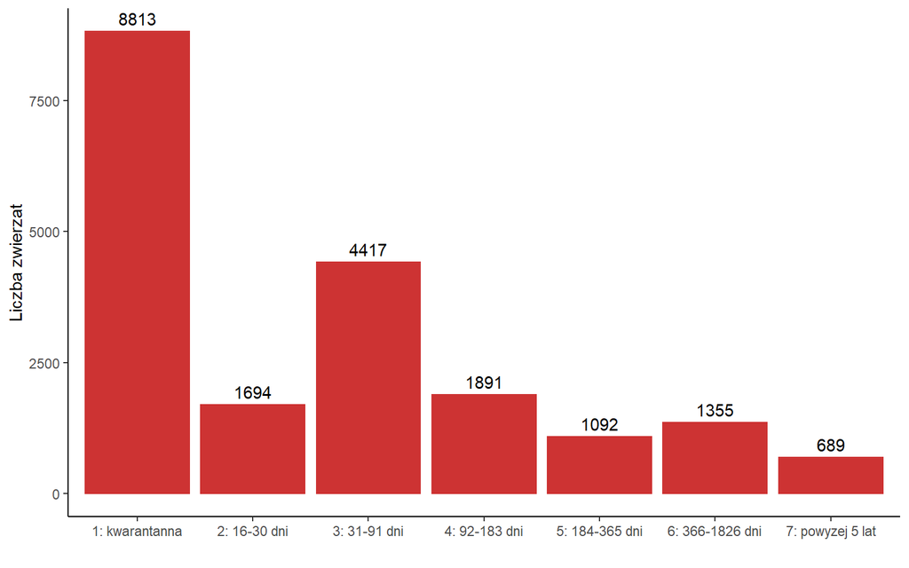

```r
a_przedzial <- animals %>%
  group_by(przedzial) %>%
  summarise(liczba = n()) %>%
  arrange(przedzial)

a_przedzial <- a_przedzial %>%
  mutate(przedzial1 = ifelse(przedzial == 1,"1: kwarantanna",
                            ifelse(przedzial == 2,"2: 16-30 dni",
                                   ifelse(przedzial == 3,"3: 31-91 dni",
                                          ifelse(przedzial == 4,"4: 92-183 dni",
                                                 ifelse(przedzial == 5,"5: 184-365 dni",
                                                        ifelse(przedzial == 6,"6: 366-1826 dni",
                                                               ifelse(przedzial == 7,"7: powyzej 5 lat","brak")))))))) %>%
  select(przedzial, przedzial1, liczba)

ggplot(a_przedzial, aes(x=factor(przedzial1), y=liczba)) +
  geom_bar(color="brown3", fill="brown3",stat="identity") +
  xlab("") +
  ylab("Liczba zwierzat") +
  geom_text(aes(label = liczba, hjust = .5, vjust = -.5))
```

## Wybranie algorytmu

Problem, który został postawiony jest zadaniem z klasyfikacji do wielu klas. Wymaga zatem zastosowania algorytmów uczenia maszynowego z nadzorem. Naszym celem jest przewidzenie, do którego z siedmiu przedziałów zostanie przypisana kolejna obserwacja, czyli jak szybko po przyjęciu do schroniska pies ma szansę na adopcję.

Biorąc po uwagę rozmiar zestawu danych, możliwości techniczne naszych komputerów oraz fakt, że dane są etykietowane (*labeled data*) i tekstowe, wybrałyśmy do sprawdzenia następujące modele: Support Vector Machine, Naiwny Klasyfikator Bayesowski, Random Forest i Extreme Gradient Boosting.

## Uczenie modelu

### Przygotowanie zbioru treningowego i testowego

Dane zostały odpowiednio sformatowane, aby mogły zostać użyte w modelach. Wartości zmiennej **przedzial1** zostały zmienione z *character* na *factor*. Pozostałe zmienne zostały zmienione na wartości liczbowe, tak aby możliwe było obliczenie ich znaczenia (*importance*) w modelach. W treningowym secie danych jest 80% danych z zestawienia *animals*.

```r
pets <- animals %>%
  select(rasa, wiek, waga, plec, przedzial, data_przyjecia, miejsce, grupa)

pets <- pets %>%
  mutate(przedzial1 = ifelse(przedzial == 1,"1: kwarantanna",
                             ifelse(przedzial == 2,"2: 16-30 dni",
                                    ifelse(przedzial == 3,"3: 31-91 dni",
                                           ifelse(przedzial == 4,"4: 92-183 dni",
                                                  ifelse(przedzial == 5,"5: 184-365 dni",
                                                         ifelse(przedzial == 6,"6: 366-1826 dni", ifelse(przedzial == 7,"7: powyzej 5 lat","brak")))))))) %>%
  mutate(msc_przyjecia = format(animals$data_przyjecia, "%m")) %>%
  select(rasa, wiek, waga, plec, msc_przyjecia,miejsce,grupa, przedzial1)
pets$przedzial1 <- as.factor(pets$przedzial1)
pets$msc_przyjecia <- as.numeric(pets$msc_przyjecia)
pets$grupa[is.na(pets$grupa)] <- 'brak'
pets$grupa[pets$grupa == 'brak'] <- 0
pets$grupa <- as.numeric(pets$grupa)

trainingindex <- createDataPartition(pets$przedzial1, p=0.8, list = FALSE)
traingset <- pets[trainingindex,]
testingset <- pets[-trainingindex,]
```

#### Support Vector Machine (polynomial kernel)

**SVM** to nadzorowany algorytm uczenia się używany głównie do klasyfikacji, ale może być również używany do regresji. Główną ideą jest to, że na podstawie oznaczonych danych (danych uczących) algorytm próbuje znaleźć optymalną hiperpłaszczyznę, którą można wykorzystać do sklasyfikowania nowych punktów danych. Na podstawie poniższych wyników można zauwazyć, że model ten ma tendencję do przypisywania wyników do przedziałów *kwarantanna* oraz *31-39 dni*.

```r
set.seed(100)
mod1 <- train(przedzial1 ~ .,data = traingset,
               method = "svmPoly",
               na.action = na.omit,
               preProcess=c("scale","center"),
              trControl = trainControl(method = "repeatedcv", number =3, repeats = 3),
               tuneGrid = data.frame(degree=1, scale = 1, C=1))

mod1.training <- predict(mod1, traingset)
mod1.training.confusion <- confusionMatrix(mod1.training, traingset$przedzial1)
print(mod1.training.confusion)
```

```
## Confusion Matrix and Statistics
##
##                   Reference
## Prediction         1: kwarantanna 2: 16-30 dni 3: 31-91 dni 4: 92-183 dni
##   1: kwarantanna             6904         1203         2623          1084
##   2: 16-30 dni                  0            0            0             0
##   3: 31-91 dni                129          143          861           393
##   4: 92-183 dni                 0            0            0             0
##   5: 184-365 dni                0            0            0             0
##   6: 366-1826 dni               6            7           32            34
##   7: powyzej 5 lat             12            3           18             2
##                   Reference
## Prediction         5: 184-365 dni 6: 366-1826 dni 7: powyzej 5 lat
##   1: kwarantanna              647             896              502
##   2: 16-30 dni                  0               0                0
##   3: 31-91 dni                196             132                9
##   4: 92-183 dni                 0               0                0
##   5: 184-365 dni                0               0                0
##   6: 366-1826 dni              25              37               15
##   7: powyzej 5 lat              6              19               26
##
## Overall Statistics
##
##                Accuracy : 0.4904
##                  95% CI : (0.4826, 0.4981)
##     No Information Rate : 0.4417
##     P-Value [Acc > NIR] : < 2.2e-16
##
##                   Kappa : 0.136
##
##  Mcnemar's Test P-Value : NA
##
## Statistics by Class:
##
##                      Class: 1: kwarantanna Class: 2: 16-30 dni Class: 3: 31-91 dni
## Sensitivity                         0.9792             0.00000             0.24363
## Specificity                         0.2197             1.00000             0.91939
## Pos Pred Value                      0.4982                 NaN             0.46216
## Neg Pred Value                      0.9302             0.91506             0.81044
## Prevalence                          0.4417             0.08494             0.22137
## Detection Rate                      0.4325             0.00000             0.05393
## Detection Prevalence                0.8681             0.00000             0.11670
## Balanced Accuracy                   0.5994             0.50000             0.58151
##                      Class: 4: 92-183 dni Class: 5: 184-365 dni
## Sensitivity                       0.00000               0.00000
## Specificity                       1.00000               1.00000
## Pos Pred Value                        NaN                   NaN
## Neg Pred Value                    0.90522               0.94525
## Prevalence                        0.09478               0.05475
## Detection Rate                    0.00000               0.00000
## Detection Prevalence              0.00000               0.00000
## Balanced Accuracy                 0.50000               0.50000
##                      Class: 6: 366-1826 dni Class: 7: powyzej 5 lat
## Sensitivity                        0.034133                0.047101
## Specificity                        0.992003                0.996107
## Pos Pred Value                     0.237179                0.302326
## Neg Pred Value                     0.933768                0.966872
## Prevalence                         0.067903                0.034578
## Detection Rate                     0.002318                0.001629
## Detection Prevalence               0.009772                0.005387
## Balanced Accuracy                  0.513068                0.521604
```

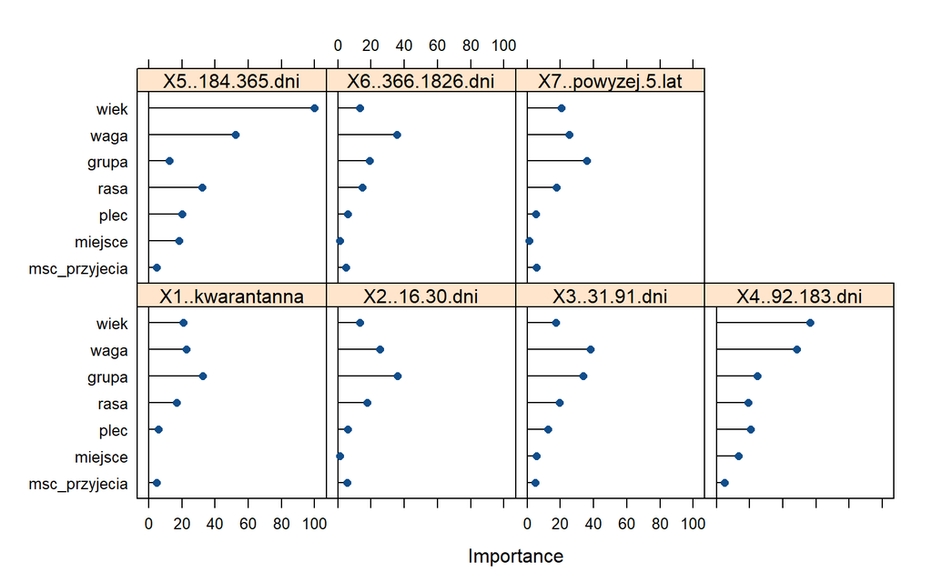

```r
Importance1 <- varImp(mod1)
plot(Importance1, col="dodgerblue4")
```

#### Naiwny Klasyfikator Bayesowski

**Naive Bayes** to nadzorowany nieliniowy algorytm klasyfikacji. Naiwne klasyfikatory Bayesa to rodzina prostych klasyfikatorów probabilistycznych opartych na zastosowaniu twierdzenia Bayes’a z silnymi (naiwnymi) założeniami niezależności między cechami lub zmiennymi. Podobnie jak model SVM, Naive Bayes przypisuje większość zwierząt do przedziałów *kwarantanna* oraz *31-39 dni*.

```r
mod2 <- train(przedzial1 ~ .,data = traingset,
                  method = "naive_bayes",
                  na.action = na.omit,
                  trControl = trainControl(method = "repeatedcv", number = 3, repeats = 3))
mod2.training <- predict(mod2, traingset)
mod2.training.confusion <- confusionMatrix(mod2.training, traingset$przedzial1)
print(mod2.training.confusion)
```

```
## Confusion Matrix and Statistics
##
##                   Reference
## Prediction         1: kwarantanna 2: 16-30 dni 3: 31-91 dni 4: 92-183 dni
##   1: kwarantanna             7014         1208         2438          1002
##   2: 16-30 dni                  3            3            2             1
##   3: 31-91 dni                 30          138         1063           459
##   4: 92-183 dni                 0            1            9            27
##   5: 184-365 dni                0            0            0             0
##   6: 366-1826 dni               2            3           20            20
##   7: powyzej 5 lat              2            3            2             4
##                   Reference
## Prediction         5: 184-365 dni 6: 366-1826 dni 7: powyzej 5 lat
##   1: kwarantanna              575             806              463
##   2: 16-30 dni                  1               0                0
##   3: 31-91 dni                261             187               12
##   4: 92-183 dni                11              17                0
##   5: 184-365 dni                0               2                0
##   6: 366-1826 dni              19              49               16
##   7: powyzej 5 lat              7              23               61
##
## Overall Statistics
##
##                Accuracy : 0.5147
##                  95% CI : (0.5069, 0.5225)
##     No Information Rate : 0.4417
##     P-Value [Acc > NIR] : < 2.2e-16
##
##                   Kappa : 0.1848
##
##  Mcnemar's Test P-Value : < 2.2e-16
##
## Statistics by Class:
##
##                      Class: 1: kwarantanna Class: 2: 16-30 dni Class: 3: 31-91 dni
## Sensitivity                         0.9948           0.0022124             0.30079
## Specificity                         0.2716           0.9995208             0.91255
## Pos Pred Value                      0.5193           0.3000000             0.49442
## Neg Pred Value                      0.9849           0.9151937             0.82112
## Prevalence                          0.4417           0.0849411             0.22137
## Detection Rate                      0.4394           0.0001879             0.06659
## Detection Prevalence                0.8460           0.0006264             0.13468
## Balanced Accuracy                   0.6332           0.5008666             0.60667
##                      Class: 4: 92-183 dni Class: 5: 184-365 dni
## Sensitivity                      0.017845             0.0000000
## Specificity                      0.997370             0.9998675
## Pos Pred Value                   0.415385             0.0000000
## Neg Pred Value                   0.906535             0.9452450
## Prevalence                       0.094776             0.0547482
## Detection Rate                   0.001691             0.0000000
## Detection Prevalence             0.004072             0.0001253
## Balanced Accuracy                0.507608             0.4999337
##                      Class: 6: 366-1826 dni Class: 7: powyzej 5 lat
## Sensitivity                        0.045203                0.110507
## Specificity                        0.994624                0.997340
## Pos Pred Value                     0.379845                0.598039
## Neg Pred Value                     0.934638                0.969046
## Prevalence                         0.067903                0.034578
## Detection Rate                     0.003069                0.003821
## Detection Prevalence               0.008081                0.006389
## Balanced Accuracy                  0.519913                0.553923
```

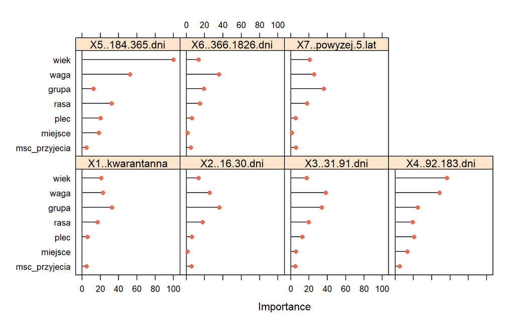

```r
Importance2 <- varImp(mod2)
plot(Importance2, col="coral2")
```

#### Random Forest

**Random Forest** to metoda zespołowa uczenia maszynowego dla klasyfikacji, regresji i innych zadań, która polega na konstruowaniu wielu drzew decyzyjnych w czasie uczenia i generowaniu klasy, która jest dominantą klas (klasyfikacja) lub przewidywaną średnią (regresja) poszczególnych drzew. Ten model w porównaniu do powyższych, wykorzystuje w dużej mierze czynnik *grupa* do określenia przedziałów, co jest widoczne na wykresie ze znaczeniem (*importance*).

```r
mod3 <- train(przedzial1 ~ .,
              data = traingset,
              method = "rf",
              ntree = 1000,
              na.action = na.omit,
              importance = TRUE,
              trControl = trainControl(method = "repeatedcv", number = 3, repeats = 3))

mod3.training <- predict(mod3, traingset)
mod3.training.confusion <- confusionMatrix(mod3.training, traingset$przedzial1)
print(mod3.training.confusion)
```

```
## Confusion Matrix and Statistics
##
##                   Reference
## Prediction         1: kwarantanna 2: 16-30 dni 3: 31-91 dni 4: 92-183 dni
##   1: kwarantanna             6981         1127         2209           928
##   2: 16-30 dni                  0          117            4             0
##   3: 31-91 dni                 20          102         1297           225
##   4: 92-183 dni                 0            0            1           341
##   5: 184-365 dni                0            0            0             0
##   6: 366-1826 dni               3            3           10             6
##   7: powyzej 5 lat             47            7           13            13
##                   Reference
## Prediction         5: 184-365 dni 6: 366-1826 dni 7: powyzej 5 lat
##   1: kwarantanna              514             621              263
##   2: 16-30 dni                  0               0                0
##   3: 31-91 dni                125              56                1
##   4: 92-183 dni                 2               1                0
##   5: 184-365 dni              206               2                0
##   6: 366-1826 dni              12             348                9
##   7: powyzej 5 lat             15              56              279
##
## Overall Statistics
##
##                Accuracy : 0.5994
##                  95% CI : (0.5918, 0.607)
##     No Information Rate : 0.4417
##     P-Value [Acc > NIR] : < 2.2e-16
##
##                   Kappa : 0.3527
##
##  Mcnemar's Test P-Value : NA
##
## Statistics by Class:
##
##                      Class: 1: kwarantanna Class: 2: 16-30 dni Class: 3: 31-91 dni
## Sensitivity                         0.9901            0.086283             0.36701
## Specificity                         0.3647            0.999726             0.95744
## Pos Pred Value                      0.5522            0.966942             0.71030
## Neg Pred Value                      0.9789            0.921795             0.84177
## Prevalence                          0.4417            0.084941             0.22137
## Detection Rate                      0.4373            0.007329             0.08125
## Detection Prevalence                0.7920            0.007580             0.11438
## Balanced Accuracy                   0.6774            0.543005             0.66222
##                      Class: 4: 92-183 dni Class: 5: 184-365 dni
## Sensitivity                       0.22538               0.23570
## Specificity                       0.99972               0.99987
## Pos Pred Value                    0.98841               0.99038
## Neg Pred Value                    0.92496               0.95760
## Prevalence                        0.09478               0.05475
## Detection Rate                    0.02136               0.01290
## Detection Prevalence              0.02161               0.01303
## Balanced Accuracy                 0.61255               0.61778
##                      Class: 6: 366-1826 dni Class: 7: powyzej 5 lat
## Sensitivity                         0.32103                 0.50543
## Specificity                         0.99711                 0.99020
## Pos Pred Value                      0.89003                 0.64884
## Neg Pred Value                      0.95274                 0.98243
## Prevalence                          0.06790                 0.03458
## Detection Rate                      0.02180                 0.01748
## Detection Prevalence                0.02449                 0.02694
## Balanced Accuracy                   0.65907                 0.74782
```

[figure not shown]

```r
Importance3 <- varImp(rf_traingset)
plot(Importance3, col="hotpink4")
```

#### Extreme Gradient Boosting

**XGBOOST** odnosi się do klasy algorytmów uczenia maszynowego w zespole, których można używać do rozwiązywania problemów związanych z klasyfikacją lub modelowaniem predykcyjnym regresji. Zespoły są zbudowane z modeli drzew decyzyjnych. Drzewa są dodawane pojedynczo do zespołu i dostosowywane do korygowania błędów przewidywania popełnionych przez poprzednie modele. Model przwiduje wyniki głównie w opraciu o grupę, wiek i wagę. Przypisywanie do grup jest bardziej różnorodne niż w powyższych modelach.

```r
mod4 <- train(przedzial1 ~ .,
                           data = traingset,
                          method = "xgbTree",
                           na.action = na.omit,
                           trControl = trainControl(method = "repeatedcv", number = 3, repeats = 3))

mod4.training <- predict(mod4, traingset)
mod4.training.confusion <- confusionMatrix(mod4.training, traingset$przedzial1)
print(mod4.training.confusion)
```

```
## Confusion Matrix and Statistics
##
##                   Reference
## Prediction         1: kwarantanna 2: 16-30 dni 3: 31-91 dni 4: 92-183 dni
##   1: kwarantanna             6808         1149         2315           935
##   2: 16-30 dni                  6           21            7             2
##   3: 31-91 dni                 70          153         1089           409
##   4: 92-183 dni                 1            0           27            81
##   5: 184-365 dni                1            3           17             6
##   6: 366-1826 dni              45           19           52            51
##   7: powyzej 5 lat            120           11           27            29
##                   Reference
## Prediction         5: 184-365 dni 6: 366-1826 dni 7: powyzej 5 lat
##   1: kwarantanna              506             603              231
##   2: 16-30 dni                  0               0                0
##   3: 31-91 dni                220             120                3
##   4: 92-183 dni                29              23                1
##   5: 184-365 dni               28              14                1
##   6: 366-1826 dni              52             185               44
##   7: powyzej 5 lat             39             139              272
##
## Overall Statistics
##
##                Accuracy : 0.5314
##                  95% CI : (0.5237, 0.5392)
##     No Information Rate : 0.4417
##     P-Value [Acc > NIR] : < 2.2e-16
##
##                   Kappa : 0.2437
##
##  Mcnemar's Test P-Value : < 2.2e-16
##
## Statistics by Class:
##
##                      Class: 1: kwarantanna Class: 2: 16-30 dni Class: 3: 31-91 dni
## Sensitivity                         0.9655            0.015487             0.30815
## Specificity                         0.3561            0.998973             0.92156
## Pos Pred Value                      0.5426            0.583333             0.52762
## Neg Pred Value                      0.9289            0.916185             0.82410
## Prevalence                          0.4417            0.084941             0.22137
## Detection Rate                      0.4265            0.001315             0.06822
## Detection Prevalence                0.7860            0.002255             0.12929
## Balanced Accuracy                   0.6608            0.507230             0.61486
##                      Class: 4: 92-183 dni Class: 5: 184-365 dni
## Sensitivity                      0.053536              0.032037
## Specificity                      0.994395              0.997217
## Pos Pred Value                   0.500000              0.400000
## Neg Pred Value                   0.909379              0.946772
## Prevalence                       0.094776              0.054748
## Detection Rate                   0.005074              0.001754
## Detection Prevalence             0.010148              0.004385
## Balanced Accuracy                0.523965              0.514627
##                      Class: 6: 366-1826 dni Class: 7: powyzej 5 lat
## Sensitivity                         0.17066                 0.49275
## Specificity                         0.98233                 0.97632
## Pos Pred Value                      0.41295                 0.42700
## Neg Pred Value                      0.94206                 0.98173
## Prevalence                          0.06790                 0.03458
## Detection Rate                      0.01159                 0.01704
## Detection Prevalence                0.02806                 0.03990
## Balanced Accuracy                   0.57649                 0.73454
```

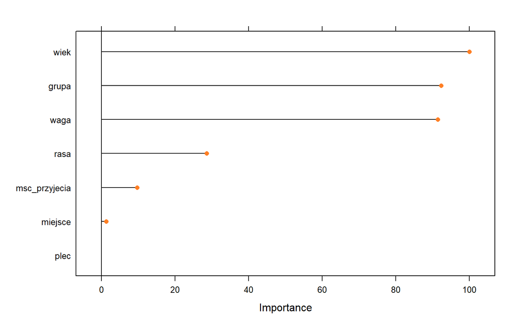

```r
Importance4 <- varImp(mod4)
plot(Importance4, col="chocolate1")
```

## Ocena wyników i podsumowanie

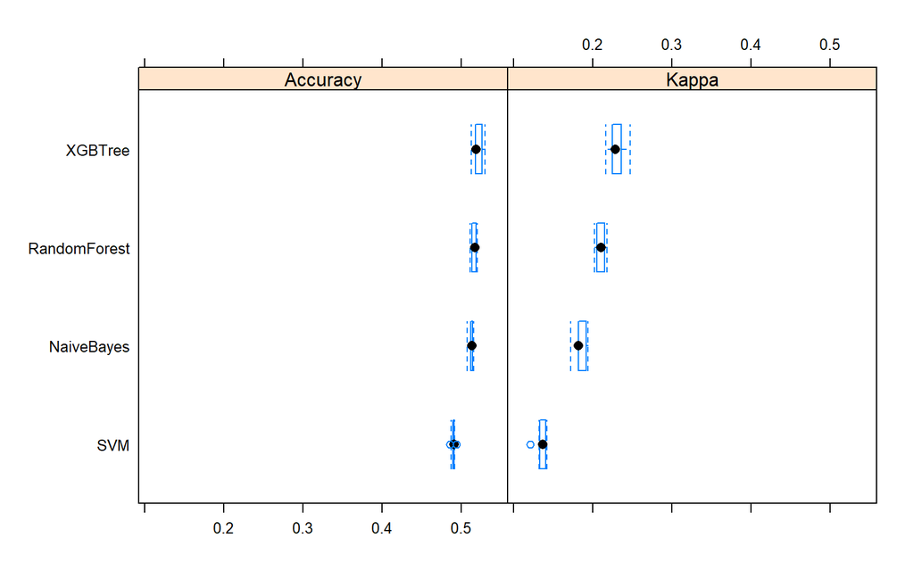

```r
results <- resamples(list(SVM = mod1, NaiveBayes = mod2, RandomForest = mod3, XGBTree = mod4))
bwplot(results)
```

```r
summary(results)
```

```
##
## Call:
## summary.resamples(object = results)
##
## Models: SVM, NaiveBayes, RandomForest, XGBTree
## Number of resamples: 9
##
## Accuracy
##                   Min.   1st Qu.    Median      Mean   3rd Qu.      Max. NA's
## SVM          0.4857197 0.4892897 0.4908852 0.4899984 0.4908852 0.4938921    0
## NaiveBayes   0.5077039 0.5117459 0.5134323 0.5130503 0.5144682 0.5156925    0
## RandomForest 0.5111821 0.5131530 0.5172867 0.5163702 0.5188874 0.5198197    0
## XGBTree      0.5124014 0.5181357 0.5189850 0.5213605 0.5258313 0.5298760    0
##
## Kappa
##                   Min.   1st Qu.    Median      Mean   3rd Qu.      Max. NA's
## SVM          0.1211330 0.1332003 0.1371504 0.1359069 0.1408990 0.1420667    0
## NaiveBayes   0.1721321 0.1815622 0.1820832 0.1845512 0.1918070 0.1937003    0
## RandomForest 0.2025590 0.2049779 0.2103259 0.2102467 0.2151845 0.2176157    0
## XGBTree      0.2166123 0.2250090 0.2285822 0.2312633 0.2360332 0.2470136    0
```